# Capstone-Milestone Report

George Akech

February 12, 2017

#### Goal

The goal of this capstone project is to build a predictive text model application which demostrate and display how we work with the data.

To show we are on track to create prediction algorithm, we need to:

1. Demonstrate that we have downloaded the data and have successfully loaded it in.
2. Create a basic report of summary statistics about the data sets.
3. Report any interesting findings that we have amassed so far.
4. Get feedback on the plans for creating a prediction algorithm and Shiny app.

#### Report

The milestone report show that when users provide unigram, bigram, trigram or a phrase and the application attempts to predict the next word. The model is trained using a corpus (a collection of English text) that is compiled from 3 sources - news, blogs, and tweets

#### 1. Set up Working Directory

```r
setwd("C:/Users/Family/Desktop/Coursera/CAPSTONE/FPReport")
```

#### 2. Set up Libraries

```r
library(knitr)
library(dplyr, quietly = TRUE, warn.conflicts = FALSE)
library(doParallel, quietly = TRUE, warn.conflicts = FALSE)
library(stringi, quietly = TRUE, warn.conflicts = FALSE) # stats files
library(NLP, quietly = TRUE, warn.conflicts = FALSE)
library(openNLP, quietly = TRUE, warn.conflicts = FALSE )
library(tm, quietly = TRUE, warn.conflicts = FALSE ) # Text mining
library(rJava, quietly = TRUE, warn.conflicts = FALSE )
library(RWeka, quietly = TRUE, warn.conflicts = FALSE) # tokenizer - create unigrams, bigrams, trigrams
library(RWekajars, quietly = TRUE, warn.conflicts = FALSE)
library(SnowballC, quietly = TRUE, warn.conflicts = FALSE) # Stemming
library(RColorBrewer, quietly = TRUE, warn.conflicts = FALSE) # Color palettes
library(qdap, quietly = TRUE, warn.conflicts = FALSE)
```

```r
library(wordcloud,quietly = TRUE, warn.conflicts = FALSE)
library(ggplot2, quietly = TRUE, warn.conflicts = FALSE ) #visualization
library(gridExtra,quietly = TRUE, warn.conflicts = FALSE)
library(shinythemes,quietly = TRUE, warn.conflicts = FALSE)
```

#### 3. Download the data from HC Corpora

The data from HC Corpora comes in 4 languages. This report uses US-English. This dataset has three files - en_US.blogs.txt,en_US.news.txt and en_US.twitter.txt.

```r
if(!file.exists("data")) {dir.create("./data")
fileUrl <- "https://d396qusza40orc.cloudfront.net/dsscapstone/dataset/Coursera-SwiftKey.zip"
download.file(fileUrl, destfile = "./data/Coursera-SwiftKey.zip")
unzip("./data/Coursera-SwiftKey.zip", exdir = "./data")}
```

#### 4. Set communication path for reading the files

```r
path1 <- "./data/final/en_US/en_US.blogs.txt"
path2 <- "./data/final/en_US/en_US.news.txt"
path3 <- "./data/final/en_US/en_US.twitter.txt"
```

#### 5. Read the files

```r
conn <- file(path1, open="rb");blogs <- readLines(conn, encoding="UTF-8", skipNul=TRUE); close(conn)
conn <- file(path2, open="rb");news <- readLines(conn, encoding="UTF-8",skipNul = TRUE); close(conn)
conn <- file(path3, open="rb");twitter <- readLines(conn, encoding="UTF-8",skipNul = TRUE); close(conn)
rm(conn)
```

#### 6. Summary Statistics

```r
stats_for_raw <- data.frame(
            FileName=c("en_US.blogs","en_US.news","en_US.twitter"),
            FileSizeinMB=c(file.info(path1)$size/1024^2,
                           file.info(path2)$size/1024^2,
                           file.info(path3)$size/1024^2),
            t(rbind(sapply(list(blogs,news,twitter),stri_stats_general),
            WordCount=sapply(list(blogs,news,twitter),stri_stats_latex)[4,]))
            )
kable(stats_for_raw)
```

| FileName | FileSizeinMB | Lines | LinesNEmpty | Chars | CharsNWhite | WordCount |
| --- | --- | --- | --- | --- | --- | --- |
| en_US.blogs | 200.4242 | 899288 | 899288 | 206824382 | 170389539 | 37570839 |
| en_US.news | 196.2775 | 1010242 | 1010242 | 203223154 | 169860866 | 34494539 |
| en_US.twitter | 159.3641 | 2360148 | 2360148 | 162096241 | 134082806 | 30451170 |

#### 7. Longest line

```r
mblog <- max(nchar(blogs))
mnews <- max(nchar(news))
mtwitter <- max(nchar(twitter))
A=matrix(c(mblog,mnews,mtwitter),nrow = 1,ncol = 3, byrow = TRUE)
#dimnames(A) = list(c("mlog","mnews","mtwitter"))
dimnames(A)=list(("MaxNChar"), c("Blogs","News","Twitter"))
head.matrix(A)
```

```
##          Blogs  News Twitter
## MaxNChar 40833 11384     140
```

```r
#row(mblog,mnews,mtwitter)
```

#### 9. Data Sample (subset)

The data is enormous and could have poor performance in mobile. So, we must create a subset of the data considering the limited resources for test and application. Let’s generate a data sample from the three files (blogs, news, Twitter)

###### 9.1 Simple Random sampling

```r
set.seed(8000)
sampleB <- blogs[sample(1:length(blogs), 8000, replace=FALSE)]
sampleN <- news[sample(1:length(news), 8000, replace=FALSE)]
sampleT <- twitter[sample(1:length(twitter), 8000, replace=FALSE)]
#-----------
N1 <- NROW(sampleB)
N2 <- NROW(sampleN)
N3 <- NROW(sampleT)
sampleTotal <- c(sampleB, sampleN,sampleT)
C <- length(sampleTotal)

B =matrix(c(N1,N2,N3),nrow = 1,ncol = 3, byrow = TRUE)
dimnames(B)=list(("NRows"), c(" sampleB"," sampleN"," sampleT"))
head.matrix(B)
```

```
##        sampleB  sampleN  sampleT
## NRows     8000     8000     8000
```

```r
K <-length(sampleTotal)
#"Total" <-head(K)
#head(Total)
#-------
#NROW(sampleB);NROW(sampleN);NROW(sampleT)
#sampleTotal <- c(sampleB, sampleN,sampleT)
#length(sampleTotal)
writeLines(sampleTotal, "./sampleTotal.txt")
```

#### 9.2 Remove what is not required

```r
writeLines(Docs3 <- c(sampleB,sampleN,sampleT), "./sample/Docs3.txt")
```

#### 10. Sample dataframe

```r
NDF <- list(sampleB,sampleN,sampleT)
corpus <- list()
dtMatrix <- list()
```

#### 11. Clean Sample data

```r
# Iterate each sampled corpus data to clean up and create DTM
for (i in 1:length(NDF)) {
    # Create corpus dataset
   corpus[[i]] <- Corpus(VectorSource(NDF[[i]]))
    # Cleaning Up corpus dataset
   corpus[[i]] <- tm_map(corpus[[i]], tolower)
    # Eleminate punctuation
    corpus[[i]] <- tm_map(corpus[[i]], removePunctuation)
    # Eleminate numbers
    corpus[[i]] <- tm_map(corpus[[i]], removeNumbers)
    # Strip Whitespace
    corpus[[i]] <- tm_map(corpus[[i]], stripWhitespace)
    # Eliminate profane words
    profanewords <- readLines("./sample/Docs3.txt", n = 600)
    #corpus[[i]] <- tm_map(corpus[[i]], removeWords, profanewords)
    # Eleminate English stop words
    corpus[[i]] <- tm_map(corpus[[i]], removeWords, stopwords("english"))
    # Perform stemming
    corpus[[i]] <- tm_map(corpus[[i]], stemDocument)
    # Create plain text format
    corpus[[i]] <- tm_map(corpus[[i]], PlainTextDocument)
    # Calculate document term frequency for corpus
    dtMatrix[[i]] <- DocumentTermMatrix(corpus[[i]], control=list(wordLengths=c(0,Inf)))
}
# Eleminate temporary variables
rm(NDF)
```

#### 12. corpus with wordcloud

[figure not shown]

#### 13. Ngram Tokenization

```r
# Define a function to make Unigram, Bigram and Trigram from the corpus
# And then Plot them together with ggplot2 and gridExtra packages
plot.Grams <- function (x=sampleB, subTitle="blogs", N=10) {
# Use RWeka to get unigram token
Tokenizer1 <- RWeka::NGramTokenizer(x, Weka_control(min = 1, max = 1))
UniGram <- data.frame(table(Tokenizer1))
head(UniGram)
UniGram <- UniGram[order(UniGram$Freq, decreasing = TRUE),]
colnames(UniGram) <- c("Word", "Freq")
UniGram <- head(UniGram, N)
g1 <- ggplot(UniGram, aes(x=reorder(Word, Freq),y=Freq)) +
        geom_bar(stat="identity", fill="gray") +
        ggtitle(paste("unigrams", "-", subTitle)) +
        xlab("unigrams") + ylab("Frequency") +
        theme(axis.text.x=element_text(angle=90, hjust=1))
# Use RWeka to get bigram token
Tokenizer2 <- RWeka::NGramTokenizer(x, Weka_control(min = 2, max = 2,
                                                          delimiters = " \\r\\n\\t.,;:\"()?!"))
BiGram <- data.frame(table(Tokenizer2))
BiGram <- BiGram[order(BiGram$Freq, decreasing = TRUE),]
colnames(BiGram) <- c("Word", "Freq")
BiGram <- head(BiGram, N)
g2 <- ggplot(BiGram, aes(x=reorder(Word, Freq),y=Freq)) +
        geom_bar(stat="identity", fill="light blue") +
        ggtitle(paste("bigrams", "-", subTitle)) +
        xlab("bigrams") + ylab("Frequency") +
        theme(axis.text.x=element_text(angle=90, hjust=1))
# Use RWeka to get trigram token
Tokenizer3 <- RWeka::NGramTokenizer(sampleB, Weka_control(min = 3, max = 3,
                                                          delimiters = " \\r\\n\\t.,;:\"()?!"))
TriGram <- data.frame(table(Tokenizer3))
TriGram <- TriGram[order(TriGram$Freq, decreasing = TRUE),]
colnames(TriGram) <- c("Word", "Freq")
TriGram <- head(TriGram, N)
g3 <- ggplot(TriGram, aes(x=reorder(Word, Freq),y=Freq)) +
        geom_bar(stat="identity", fill="green") +
        ggtitle(paste("trigrams", "-", subTitle)) +
        xlab("trigrams") + ylab("Frequency") +
        theme(axis.text.x=element_text(angle=90, hjust=1))
# Put three plots into 1 row 3 columns
gridExtra::grid.arrange(g1, g2, g3, ncol = 3)
}
```

#### 14. Plot the frequencies

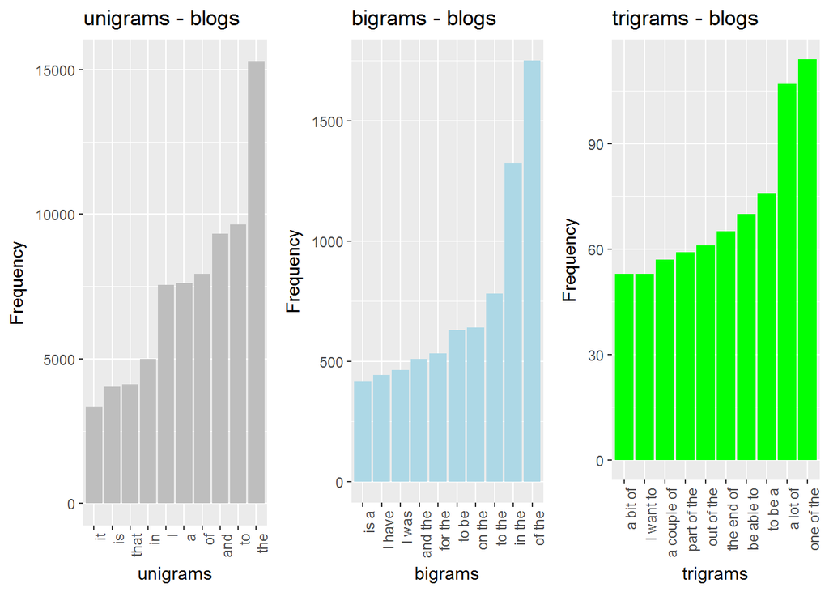

```r
plot.Grams(x = sampleB, subTitle = "blogs", N = 10)
```

[figure not shown]

```r
plot.Grams(x = sampleN, subTitle = "news", N = 10)
```

[figure not shown]

```r
plot.Grams(x = sampleT, subTitle = "twitter", N = 10)
```

#### 15. Next Steps For Prediction Algorithm And Shiny App

1. This concludes our exploratory analysis. The next steps of this capstone project would be to finalize our predictive algorithm, and deploy our algorithm as a Shiny app.
2. The predictive algorithm will be using n-gram model with frequency lookup similar to our exploratory analysis above. One possible strategy would be to use the trigram model to predict the next word. If no matching trigram can be found, then the algorithm would back off to the bigram model, and then to the unigram model if needed.
3. The user interface of the Shiny app will consist of a text input box that will allow a user to enter a phrase. Then the app will use our algorithm to suggest the most likely next word after a short delay. Our plan is also to allow the user to configure how many words our app should suggest.